# Intro to health data analysis in R

## Background

Today we want to demonstrate how R can provide a one-stop-shop for health data analysis.

We’ll start with base R today, and show how [dplyr](https://cran.rstudio.com/web/packages/dplyr/vignettes/introduction.html) makes life easier.

To start, we’ll use publicly available data on county-by-county health statistics for 2015.

## Follow along

If interested

- Download the data from [here](http://www.countyhealthrankings.org/sites/default/files/2015%20CHR%20Analytic%20Data.csv)
- Install dplyr. Enter into the command line: install.packages(c(“dplyr”,“choroplethr”,“choroplethrMaps”))
- Go to RStudio –> File –> New Rscript and copy in the code snippets that follow.
- To get a better understanding, comment out certain lines (using #), and then run the script again.
- Note you can run the entire script via CTRL-SHIFT-ENTER or run the script just to your cursor via CTRL-ALT-b
- If you get stuck, you can pull up documents via `?functionName` like `?read.csv`

## Getting started

When you turn to Excel to analyze data, what are you typically trying to do? Perhaps you’re looking for

- Easy sorting or filtering
- Pivot tables
- Simple calculations
- Simple plots

Let’s show you how to do the same in R.

Note that dataframes are the most popular way in R to work with tabular data, and we’ll focus on them throughout this tutorial.

First, let’s load in the csv file and store it in a [dataframe](http://www.r-tutor.com/r-introduction/data-frame) called df.

```r
df <- read.csv('2015 CHR Analytic Data.csv') #  You may want a path here, using /forward/slashes
```

## Looking at data in RStudio

Now that we’ve read in the data, note that you see a df entry under your Environment tab.

Note that `df` has 3191 obs (i.e., rows, representing counties) and 329 variables (i.e., columns or metrics).

329 columns is a lot. Let’s create a smaller dataset that’s based only on our columns of interest.

*Besides the state and county column, we’ll grab county data on*

1. The percentage of county births that are under 5 lbs 8 oz (i.e., [low-birth weight or LBW](http://www.countyhealthrankings.org/our-approach/health-outcomes/birth-outcomes)).
2. [Median household income](http://www.countyhealthrankings.org/measure/median-household-income)
3. Percentage of individuals [drinking heavily](http://www.countyhealthrankings.org/measure/excessive-drinking) in the last 30 days.

```r
# Remove state summary rows
df <- subset(df, COUNTYCODE != 0)
# Remove commas from income column
df$Median.household.income.Value <- as.numeric(gsub(",", "", df$Median.household.income.Value))
# Create a smaller dataframe, with just a few cols
colList <- c('State',
             'County',
             'Low.birthweight.Value',
             'Median.household.income.Value',
             'Excessive.drinking.Value')
dfSmall <- subset(df, select = colList)
```

Look again in the Environment tab, double-click on `df_small`, and you’ll see an Excel-like view open. You’ll notice that you can easily

1. Sort the dataset in both directions by each column
2. Filter the rows displayed based on sliders or an input value for a particular column (i.e., counties in Nevada)

*Note:* you can also bring up the interactive tab via `View(df)`

## Sorting and filtering in RStudio

*NOW YOU TRY:*

Use the df interactive tab to find the counties in Utah with the highest rate of low-birth weight (LBW) births.

Besides the interactive route, note that there’s always a code-based way of doing the same thing.

Let’s list the five counties with the highest rate of LBW in Utah (using [base R](https://www.rstudio.com/wp-content/uploads/2016/05/base-r.pdf)):

```r
# Order the dataframe by LBW (descending)
dfUtah <- subset(dfSmall, State == 'UT')
dfUtahOrdered <- dfUtah[with(dfUtah, order(Low.birthweight.Value, decreasing = TRUE)),]
# Print first five rows of dataframe
head(dfUtahOrdered, n = 5)
```

|  | State | County | Low.birthweight.Value | Median.household.income.Value | Excessive.drinking.Value |
| --- | --- | --- | --- | --- | --- |
| 2823 | UT | Carbon County | 0.09 | 44594 | 0.114 |
| 2827 | UT | Emery County | 0.09 | 52070 | 0.105 |
| 2840 | UT | Sevier County | 0.09 | 49877 | 0.096 |
| 2841 | UT | Summit County | 0.09 | 81907 | 0.191 |
| 2826 | UT | Duchesne County | 0.08 | 61386 | 0.093 |

```r
library(dplyr)
dfSmall %>%
  filter(State == "NH") %>%
  arrange((Low.birthweight.Value)) %>%
  top_n(5)
```

| State | County | Low.birthweight.Value | Median.household.income.Value | Excessive.drinking.Value |
| --- | --- | --- | --- | --- |
| NH | Carroll County | 0.06 | 50598 | 0.180 |
| NH | Grafton County | 0.06 | 55131 | 0.185 |
| NH | Hillsborough County | 0.07 | 67162 | 0.176 |
| NH | Rockingham County | 0.07 | 74785 | 0.197 |
| NH | Coos County | 0.08 | 40917 | 0.181 |

So if Carbon, Emery, Summit, and Sevier counties were listed for highest LBW, you were correct!

Notice how simple the [dplyr](https://cran.rstudio.com/web/packages/dplyr/vignettes/introduction.html) syntax is!

## Pivot tables in R

Since we have counties from multiple states in this dataset, we can easily use dplyr to get the LBW mean for each state.

```r
dfSmall %>%
  group_by(State) %>%
  summarize(LBWMean = mean(Low.birthweight.Value, na.rm = TRUE)) %>%
  arrange(LBWMean)
```

| State | LBWMean |
| --- | --- |
| AK | 0.05523810 |
| MN | 0.05954023 |
| WA | 0.06153846 |
| WI | 0.06281690 |
| CA | 0.06315789 |
| SD | 0.06410714 |
| OR | 0.06411765 |
| ND | 0.06487179 |
| ME | 0.06500000 |
| NE | 0.06500000 |

[output cut: 41 more lines]

## View the LBW as a histogram.

Similar to dplyr, ggplot2 is a fantastic add-on package that makes life easier. While dplyr focuses on analysis, ggplot focuses on plotting.

First, the most basic thing possible.

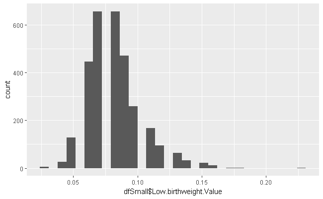

```r
library(ggplot2)
#qplot is used for really quick and dirty plots. There's less customization than ggplot.
qplot(dfSmall$Low.birthweight.Value, geom="histogram")
```

Clean up the plot

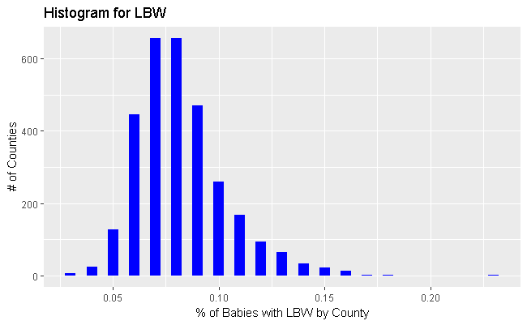

```r
#qplot is used for really quick and dirty plots. There's less customization than ggplot.
qplot(dfSmall$Low.birthweight.Value,
      binwidth = 0.005,
      main = "Histogram for LBW",
      xlab = "% of Babies with LBW by County",
      ylab = "# of Counties",
      fill = I("blue"),
      geom="histogram")
```

## A simple scatter plot

GGplot can also be used to look at the relationship between LBW and income.

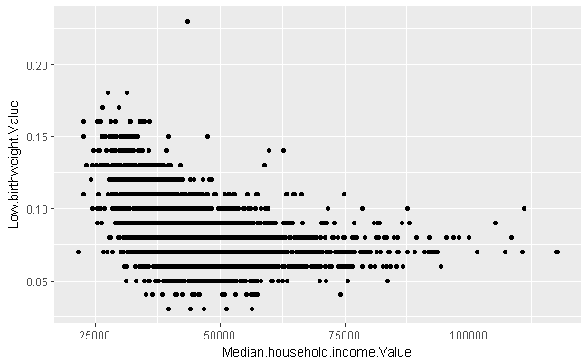

```r
library(ggplot2)
# We can use ggplot for this one.
ggplot(dfSmall, aes(x = Median.household.income.Value, y = Low.birthweight.Value)) + geom_point()
```

Okay, it appears that that higher income counties have smaller rates of LBW. Let’s fit a line to check:

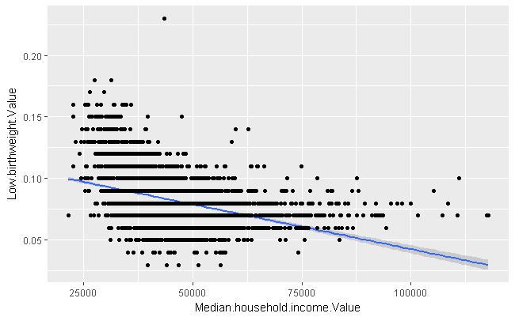

```r
c <- ggplot(dfSmall, aes(x = Median.household.income.Value, y = Low.birthweight.Value))
c + stat_smooth(method=lm) + geom_point()
```

## Let’s do a calculation to check the LBW-income relationship

Up till now, we’ve been sorting, filtering, and creating pivot tables. Let’s use a two-sample [t-test](http://www.statmethods.net/stats/ttest.html) to test the likelihood that these two vectors of LBW values come from the same distribution. In other words, we want to test if income has a significant effect on LBW rates.

Now let’s imagine that we want two vectors of LBW. One for richer states and one for poorer states. How can we do this? First, let’s create the LBW vector–think of it as a list–for states richer than the median state.

```r
richStatesLBW <-
dfSmall %>%
  group_by(State) %>%
  summarize(LBWMean = mean(Low.birthweight.Value, na.rm = TRUE), IncomeMean = mean(Median.household.income.Value, na.rm = TRUE)) %>%
  filter(IncomeMean > median(IncomeMean)) %>%
  .$LBWMean
```

Now let’s create a vector–think of a list–of LBW values for poorer states:

```r
poorStatesLBW <-
dfSmall %>%
  group_by(State) %>%
  summarize(LBWMean = mean(Low.birthweight.Value, na.rm = TRUE), IncomeMean = mean(Median.household.income.Value, na.rm = TRUE)) %>%
  filter(IncomeMean < median(IncomeMean)) %>%
  .$LBWMean
```

Vectors are ready. Run the T-Test

```r
t.test(richStatesLBW, poorStatesLBW)
```

```
    Welch Two Sample t-test

data:  richStatesLBW and poorStatesLBW
t = -2.5115, df = 44.129, p-value = 0.01576
alternative hypothesis: true difference in means is not equal to 0
95 percent confidence interval:
 -0.018691341 -0.002049278
sample estimates:
 mean of x  mean of y
0.07453657 0.08490688
```

## A more advanced example: data cleaning and choropleths.

Now we’ve fit a line and confidence interval to our data, and run a T-Test. Excel can do all of that (arguably more easily than R), but now let’s explore an example a more complicated feature that R can still do easily. This is a lot of code, but most of it is unnecessary for a single choropleth. We use it so that we can make several choropleths efficiently.

```r
removeCommasInNumber <- function(column) {
  column <- as.numeric(gsub(",", "", column))
  column
}
createChoropleth <- function(df,
                             colToPlot,
                             title,
                             legend,
                             numColors=1,
                             NAReplace=NULL) {

  library(choroplethr)
  library(choroplethrMaps)
  library(ggplot2)

  # Remove commas from column of interest
  if (!is.numeric(df[[colToPlot]])) {
    df[[colToPlot]] <- removeCommasInNumber(df[[colToPlot]])
  }

  # Remove state rows from dataset
  df <- subset(df, COUNTYCODE != 0)

  df$STATECODE <- as.integer(df$STATECODE)
  df$COUNTYCODE <- as.integer(df$COUNTYCODE)

  # Pad county digits
  df$COUNTYCODE <- sprintf("%03d", df$COUNTYCODE)

  # Concatenate and create FIPS
  df$FIPSCODE <- as.numeric(paste0(df$STATECODE,df$COUNTYCODE))

  # Reduce dataset and rename cols for county_choropleth func
  df <- subset(df, select = c('FIPSCODE', colToPlot))
  colnames(df) <- c("region","value")

  # Fill NA cells with something (so choropleth works)
  if (!is.null(NAReplace)) {
    df["value"][is.na(df["value"])] <- NAReplace
  }

  # Plot data on a US map
  county_choropleth(df, num_colors = numColors, legend = legend) +
    ggtitle(title) +
    theme(plot.title = element_text(hjust = 0.5))
}
createPercentiles <- function(x) {
  (x - min(x, na.rm = TRUE))/(max(x, na.rm = TRUE) - min(x, na.rm = TRUE))
}
```

Now, call that function on Median Household Income

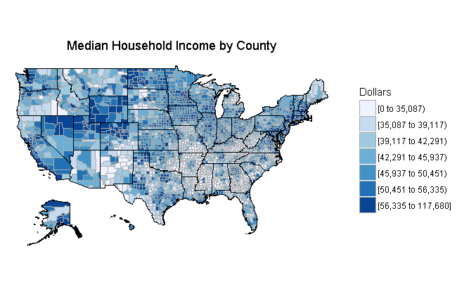

```r
# Plot choropleth
createChoropleth(df,
                 colToPlot = 'Median.household.income.Value',
                 #colToPlot = 'Premature.death.Value',
                 #colToPlot = 'Low.birthweight.Value',
                 title = 'Median Household Income by County',
                 legend = 'Dollars',
                 numColors = 7,
                 NAReplace = 0)
```